# Case Study: Predicting Airline Delays

Máster en Data Science y Big Data en Finanzas

AFI, 2022

# Introduction

On any given day, more than 90,000 flights operate in the US. About one-third of these flights are commercial flights, operated by companies like United, American Airlines, etc. Among these commercial flights, 20% suffer from delays due to various reasons. A certain number of delays are unavoidable, due to unexpected events, but some delays could hopefully be avoided if the factors causing delays are better understood and addressed.

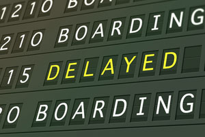

In this case study, we will use a dataset with 9,381 flights that occurred in June-August, 2014 between the three busiest US airports:

- Atlanta (ATL)
- Los Angeles (LAX)
- Chicago (ORD)

### The dataset

The dataset AirlineDelay.csv includes the following 23 variables:

- Flight = the origin-destination pair (LAX-ORD, ATL-LAX, etc.)
- Carrier = the carrier operating the flight (American Airlines, Delta Air Lines, etc.)
- Month = the month of the flight (June, July, or August)
- DayOfWeek = the day of the week of the flight (Monday, Tuesday, etc.)
- NumPrevFlights = the number of previous flights taken by this aircraft in the same day
- PrevFlightGap = the amount of time between when this flight’s aircraft is scheduled to arrive at the airport and when it’s scheduled to depart for this flight
- HistoricallyLate = the proportion of time this flight has been late historically
- InsufficientHistory = whether or not we have enough data to determine the historical record of the flight (equal to 1 if we don’t have at least 3 records, equal to 0 if we do)
- OriginInVolume = the amount of incoming traffic volume at the origin airport, normalized by the typical volume during the flight’s time and day of the week
- OriginOutVolume = the amount of outgoing traffic volume at the origin airport, normalized by the typical volume during the flight’s time and day of the week
- DestInVolume = the amount of incoming traffic volume at the destination airport, normalized by the typical volume during the flight’s time and day of the week
- DestOutVolume = the amount of outgoing traffic volume at the destination airport, normalized by the typical volume during the flight’s time and day of the week
- OriginPrecip = the amount of rain at the origin over the course of the day, in tenths of millimeters
- OriginAvgWind = average daily wind speed at the origin, in miles per hour
- OriginWindGust = fastest wind speed during the day at the origin, in miles per hour
- OriginFog = whether or not there was fog at some point during the day at the origin (1 if there was, 0 if there wasn’t)
- OriginThunder = whether or not there was thunder at some point during the day at the origin (1 if there was, 0 if there wasn’t)
- DestPrecip = the amount of rain at the destination over the course of the day, in tenths of millimeters
- DestAvgWind = average daily wind speed at the destination, in miles per hour
- DestWindGust = fastest wind speed during the day at the destination, in miles per hour
- DestFog = whether or not there was fog at some point during the day at the destination (1 if there was, 0 if there wasn’t)
- DestThunder = whether or not there was thunder at some point during the day at the destination (1 if there was, 0 if there wasn’t)
- TotalDelay = the amount of time the aircraft was delayed, in minutes (this is our dependent variable)

### The goal

Predict the response TotalDelay as a function of the other variables

### Descriptive Analysis

It is always a good idea to separate from the beginning the training set (what the tool is going to see) from the testing set (used only to validate predictions)

```r
library(tidyverse)
library(MASS)
library(caret)
library(e1071)

# Loading and preparing data
Airlines <- read.csv("AirlineDelay.csv", stringsAsFactors=T)

# split between training and testing sets
spl = createDataPartition(Airlines$TotalDelay, p = 0.8, list = FALSE)  # 80% for training

AirlinesTrain = Airlines[spl,]
AirlinesTest = Airlines[-spl,]

str(AirlinesTrain)
```

```
## 'data.frame':    7506 obs. of  23 variables:
##  $ Flight             : Factor w/ 6 levels "ATL-LAX","ATL-ORD",..: 4 4 4 4 4 4 4 4 4 4 ...
##  $ Carrier            : Factor w/ 8 levels "AirTran Airways",..: 2 2 2 2 2 2 2 2 2 2 ...
##  $ Month              : Factor w/ 3 levels "August","July",..: 3 3 3 3 3 3 3 3 3 3 ...
##  $ DayOfWeek          : Factor w/ 7 levels "Friday","Monday",..: 7 5 1 4 6 7 1 3 4 6 ...
##  $ NumPrevFlights     : int  1 1 2 1 1 1 1 1 1 1 ...
##  $ PrevFlightGap      : int  55 55 35 30 55 55 55 5 55 55 ...
##  $ HistoricallyLate   : num  0 0 0 0.25 0.167 ...
##  $ InsufficientHistory: int  1 1 1 0 0 0 0 0 0 0 ...
##  $ OriginInVolume     : num  1.05 1.02 1.03 1.09 1.03 ...
##  $ OriginOutVolume    : num  1.027 1.02 0.998 1.002 1.015 ...
##  $ DestInVolume       : num  0.99 0.961 0.991 0.97 0.987 ...
##  $ DestOutVolume      : num  0.987 0.99 1.001 1.036 1.001 ...
##  $ OriginPrecip       : int  0 0 0 0 0 0 0 0 0 0 ...
##  $ OriginAvgWind      : num  9.62 8.72 7.61 7.61 7.38 ...
##  $ OriginWindGust     : num  19.9 18.1 16.1 17 17 ...
##  $ OriginFog          : int  0 0 1 0 0 0 1 0 0 1 ...
##  $ OriginThunder      : int  0 0 0 0 0 0 0 0 0 0 ...
##  $ DestPrecip         : int  132 0 0 0 0 165 3 325 0 104 ...
##  $ DestAvgWind        : num  7.38 10.07 9.84 15.66 12.53 ...
##  $ DestWindGust       : num  16.1 23.9 18.1 32 28 ...
##  $ DestFog            : int  0 0 0 0 0 0 0 0 0 0 ...
##  $ DestThunder        : int  0 0 0 0 0 0 0 0 0 0 ...
##  $ TotalDelay         : int  25 0 0 0 10 64 0 139 75 0 ...
```

```r
summary(AirlinesTrain)
```

```
##      Flight                   Carrier        Month          DayOfWeek
##  ATL-LAX:1178   Delta Air Lines   :3169   August:2550   Friday   :1107
##  ATL-ORD: 899   United Airlines   :1678   July  :2538   Monday   :1073
##  LAX-ATL:1147   American Airlines :1454   June  :2418   Saturday : 937
##  LAX-ORD:1697   Southwest Airlines: 475                 Sunday   :1134
##  ORD-ATL: 891   Virgin America    : 270                 Thursday :1092
##  ORD-LAX:1694   SkyWest Airlines  : 208                 Tuesday  :1094
##                 (Other)           : 252                 Wednesday:1069
##  NumPrevFlights  PrevFlightGap   HistoricallyLate InsufficientHistory
##  Min.   :0.000   Min.   :  1.0   Min.   :0.0000   Min.   :0.0000
##  1st Qu.:0.000   1st Qu.: 51.0   1st Qu.:0.0000   1st Qu.:0.0000
##  Median :1.000   Median : 62.0   Median :0.1379   Median :0.0000
##  Mean   :1.648   Mean   :115.3   Mean   :0.1893   Mean   :0.2768
##  3rd Qu.:3.000   3rd Qu.:240.0   3rd Qu.:0.3000   3rd Qu.:1.0000
##  Max.   :8.000   Max.   :240.0   Max.   :1.0000   Max.   :1.0000
##
##  OriginInVolume   OriginOutVolume   DestInVolume    DestOutVolume
##  Min.   :0.0000   Min.   :0.2743   Min.   :0.1116   Min.   :0.0000
##  1st Qu.:0.9705   1st Qu.:0.9776   1st Qu.:0.9749   1st Qu.:0.9601
##  Median :1.0048   Median :1.0149   Median :1.0091   Median :1.0054
##  Mean   :0.9969   Mean   :1.0109   Mean   :1.0061   Mean   :0.9524
##  3rd Qu.:1.0442   3rd Qu.:1.0508   3rd Qu.:1.0468   3rd Qu.:1.0446
##  Max.   :1.3520   Max.   :1.4312   Max.   :1.5072   Max.   :1.4896
##
##   OriginPrecip    OriginAvgWind    OriginWindGust     OriginFog
##  Min.   :  0.00   Min.   : 2.013   Min.   : 8.948   Min.   :0.0000
##  1st Qu.:  0.00   1st Qu.: 6.263   1st Qu.:14.988   1st Qu.:0.0000
##  Median :  0.00   Median : 7.606   Median :17.001   Median :0.0000
##  Mean   : 28.13   Mean   : 7.644   Mean   :18.116   Mean   :0.1226
##  3rd Qu.:  3.00   3rd Qu.: 8.724   3rd Qu.:19.909   3rd Qu.:0.0000
##  Max.   :701.00   Max.   :16.106   Max.   :44.962   Max.   :1.0000
##
##  OriginThunder       DestPrecip      DestAvgWind      DestWindGust
##  Min.   :0.00000   Min.   :  0.00   Min.   : 2.013   Min.   : 8.948
##  1st Qu.:0.00000   1st Qu.:  0.00   1st Qu.: 6.263   1st Qu.:14.988
##  Median :0.00000   Median :  0.00   Median : 7.606   Median :17.001
##  Mean   :0.02731   Mean   : 27.37   Mean   : 7.666   Mean   :18.159
##  3rd Qu.:0.00000   3rd Qu.:  3.00   3rd Qu.: 8.724   3rd Qu.:19.909
##  Max.   :1.00000   Max.   :701.00   Max.   :16.106   Max.   :44.962
##
##     DestFog        DestThunder        TotalDelay
##  Min.   :0.0000   Min.   :0.00000   Min.   :   0.00
##  1st Qu.:0.0000   1st Qu.:0.00000   1st Qu.:   0.00
##  Median :0.0000   Median :0.00000   Median :   1.00
##  Mean   :0.1203   Mean   :0.02731   Mean   :  17.67
##  3rd Qu.:0.0000   3rd Qu.:0.00000   3rd Qu.:  18.00
##  Max.   :1.0000   Max.   :1.00000   Max.   :1107.00
##
```

Insights?

### Visualization

Add here interesting plots to get information, taking into account the most important variable

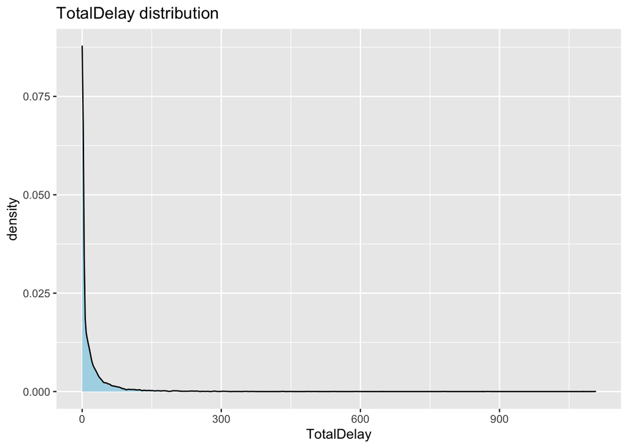

```r
ggplot(AirlinesTrain, aes(TotalDelay)) + geom_density(fill="lightblue") + xlab("TotalDelay") + ggtitle("TotalDelay distribution")
```

Highly asymmetric distribution

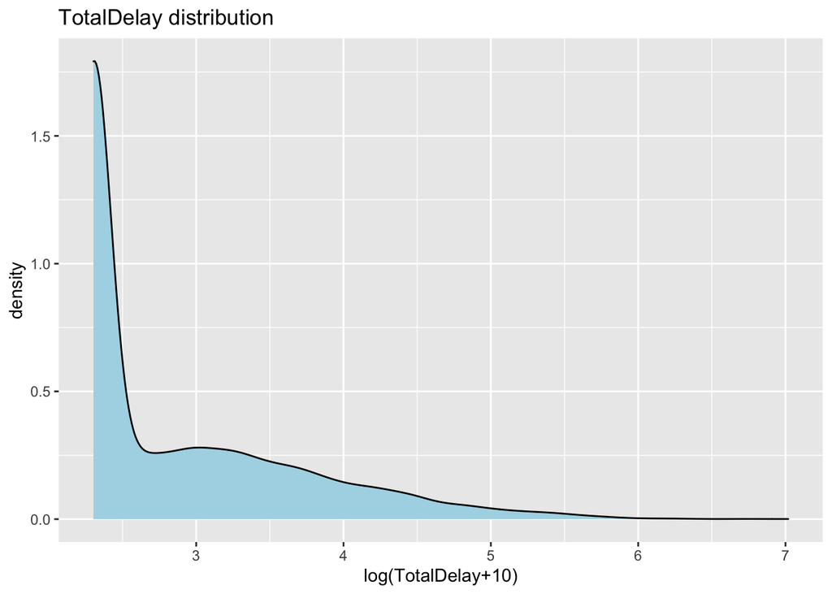

```r
ggplot(AirlinesTrain, aes(log(TotalDelay+10))) + geom_density(fill="lightblue") + xlab("log(TotalDelay+10)") + ggtitle("TotalDelay distribution")
```

Or a second group with center (mode) at 10 min

Moreover, half of the observations have a TotalDelay==0

Should we omit those observations?

```r
# AirlinesTrain = filter(AirlinesTrain, TotalDelay>0)
# AirlinesTest = filter(AirlinesTest, TotalDelay>0)
```

Any simple idea to predict delays?

```r
# For instance, we can predict all the new delays as the median delay in the training set
median(AirlinesTrain$TotalDelay)
```

```
## [1] 1
```

We can even add more visual information:

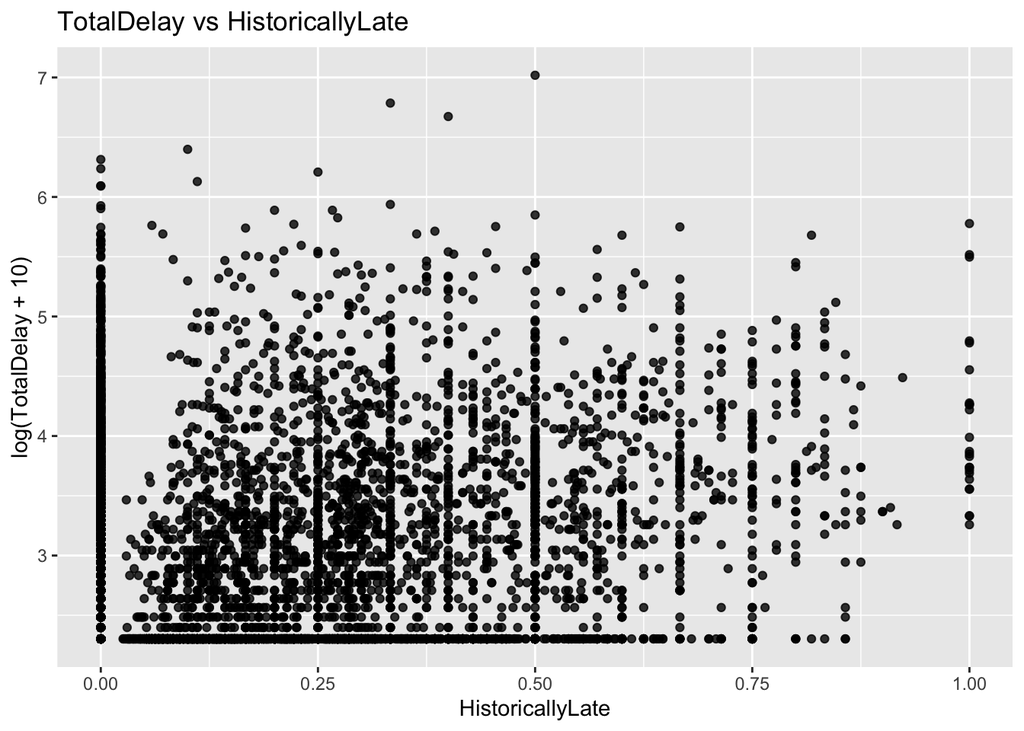

```r
# TotalDelay vs HistoricallyLate
ggplot(AirlinesTrain, aes(x=HistoricallyLate, y=log(TotalDelay+10))) +
  geom_point(alpha=0.8) + ggtitle("TotalDelay vs HistoricallyLate")
```

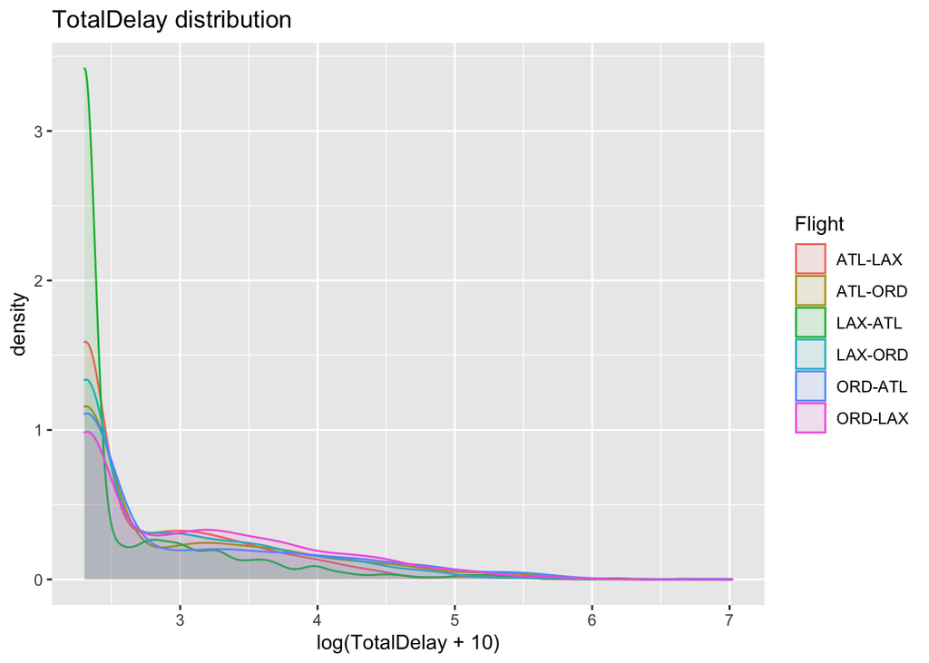

```r
# not a clear relation, maybe some non-linearities?

ggplot(AirlinesTrain, aes(log(TotalDelay+10))) + geom_density(aes(group=Flight, colour=Flight, fill=Flight), alpha=0.1) +
  ggtitle("TotalDelay distribution")
```